# RLadies Montreal Reboot: 2023-24

Kathryn Morrison, Monica Cella, Rhiannon Kamstra

2023-09-25

# RLadies Montreal Reboot: 2023-24

Welcome! Today’s agenda:

6:00 - 6:15: Settling in

6:15 - 6:30: Introductions

6:30 - 6:45: Brief history of RLadies Montreal + 2023-24 Plan

6:45 - 7:00: Introduction to data wrangling with dplyr

7:00 - 8:00: Interactive dplyr work/networking period

# Introductions: Kathryn Morrison

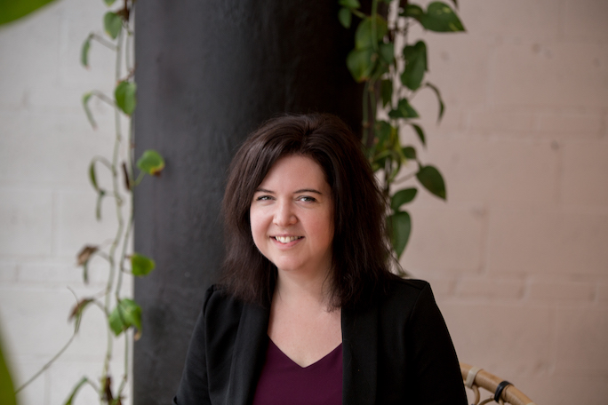

# Introductions: Monica Cella

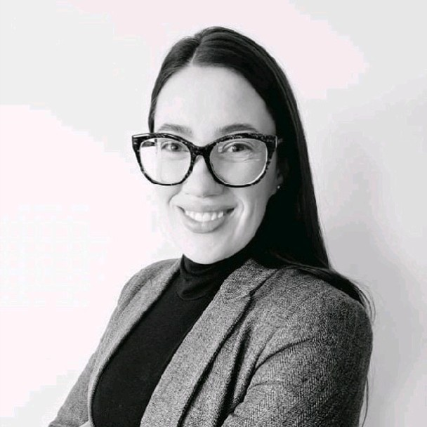

# Introductions: Rhiannon Kamstra

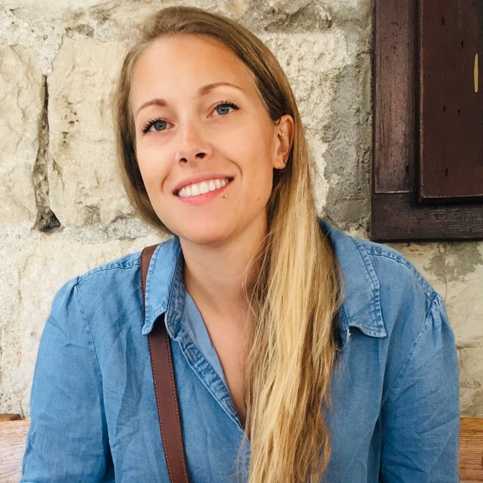

# Introductions: You!

- Name, what you do for work or study, what brought you here, anything else you want to share

[figure not shown]

# What is RLadies?

- R Ladies Global seeks to achieve proportionate representation by encouraging, inspiring, and empowering the minorities currently underrepresented in the R community

The two primary mechanisms for facilitating this change are:

1. Supporting the R enthusiasts who identify as an underrepresented minority to achieve their programming potential
2. Building a collaborative global network of R leaders, mentors, learners, and developers

# What is RLadies?

We focus on the R language/environment (but if you want to talk about python or SAS, you won’t be banned)

Represented/Majority Gender is welcome, but not prioritised

All members must follow the [RLadies Code of Conduct](https://github.com/rladies/starter-kit/blob/master/RLadiesRulesAndGuideLinesENES.md#CoCEN)

- Community driven, independent, free of charge
- Safe and friendly, zero harassment!

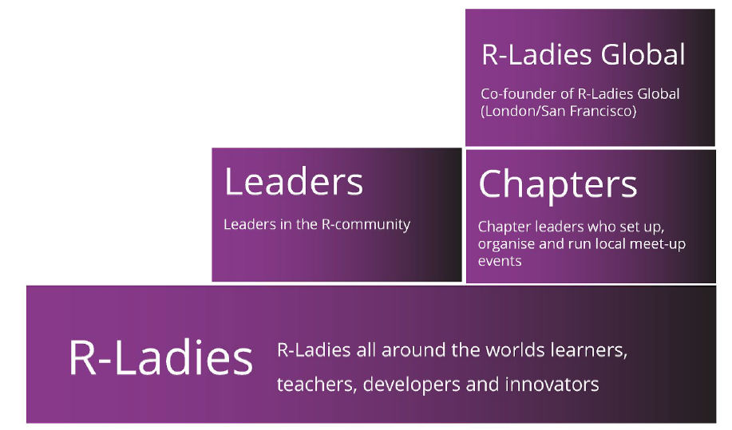

# Brief history of RLadies Montreal + plan for this year

- Started by Kathryn + Erika in March 2018, had a very active chapter until the plague hit in 2020
- Past corporate sponsors: Plotly, Upgrade, Precision Analytics
- Always looking for new sponsors and more importantly, **volunteer presenters!**
- Any topic is welcome and you don’t need to be an expert - sometimes giving an introductory workshop or lesson is the best way to learn

# Brief history of RLadies Montreal + plan for this year

- We will send out a survey with requests for specific topics
- We generally for each session, we generally follow this format:
  - a brief hello/welcome from the organizors
  - an opportunity for anyone hiring or looking for work to mention it
  - tutorial or seminar
- We’re very open to changes + suggestions!

# Brief history of RLadies Montreal + plan for this year

- Past tutorial/workshops included: data vis/ggplot2, intro to dashboard development with shiny, intro to machine learning/deep learning, intro to git/github, intro to DashR
- Past seminars included: Financial analysis in R, women in tech survey analysis, reproducibile research, spatial analysis in R, causal inference in R
- Tutorials are often brief (15-30 mins of speaking) followed by lots of “hands-on” coding time
- Seminars are also usually brief (but can be longer) follow by discussion/networking time

# Introduction to data wrangling with dplyr

- What is the dplyr package - familiar if you know SQL
- The most common “verbs”: mutate, select, filter, summarise, arrange
- Joining: left, right, inner, and full (outer) joins
- Practice time